# Project: Investigate a Dataset (Tmdb movie Dataset)

- Introduction
- Data Wrangling
- Exploratory Data Analysis
- Conclusions

# Introduction

Overview :

Questions I would answer it: 1-Is there a connection between the Runtime of the movie and its popularity? 2-Is there a connection between the budget of the movie and its Profit? 3-What is the name of the movie with the highest profit and the movie with largest budget?

```python
# Import necessary packages

import pandas as pd
import numpy as np
import seaborn as sns
import csv
import matplotlib.pyplot as plt
from datetime import datetime
import pprint
% matplotlib inline
```

# Data Wrangling

General Properties:

1- Load the data. 2- Print out a few lines of the data to observing and asking questions. 3- Look at number of rows ,columns. 4- Get the verage of the data. 5- look at the null cells. 6- Remove the duplicacy in the rows. 7- look at data type.

```python
# Load data
movies= pd.read_csv('../Investigate a Dataset/tmdb_5000_movies.csv')
```

```python
movies.head() #Print out a few lines of data
```

|  | budget | genres | homepage | id | keywords | original_language | original_title | overview | popularity | production_companies | production_countries | release_date | revenue | runtime | spoken_languages | status | tagline | title | vote_average | vote_count |
| --- | --- | --- | --- | --- | --- | --- | --- | --- | --- | --- | --- | --- | --- | --- | --- | --- | --- | --- | --- | --- |
| 0 | 237000000 | [{"id": 28, "name": "Action"}, {"id": 12, "nam... | http://www.avatarmovie.com/ | 19995 | [{"id": 1463, "name": "culture clash"}, {"id":... | en | Avatar | In the 22nd century, a paraplegic Marine is di... | 150.437577 | [{"name": "Ingenious Film Partners", "id": 289... | [{"iso_3166_1": "US", "name": "United States o... | 2009-12-10 | 2787965087 | 162.0 | [{"iso_639_1": "en", "name": "English"}, {"iso... | Released | Enter the World of Pandora. | Avatar | 7.2 | 11800 |
| 1 | 300000000 | [{"id": 12, "name": "Adventure"}, {"id": 14, "... | http://disney.go.com/disneypictures/pirates/ | 285 | [{"id": 270, "name": "ocean"}, {"id": 726, "na... | en | Pirates of the Caribbean: At World's End | Captain Barbossa, long believed to be dead, ha... | 139.082615 | [{"name": "Walt Disney Pictures", "id": 2}, {"... | [{"iso_3166_1": "US", "name": "United States o... | 2007-05-19 | 961000000 | 169.0 | [{"iso_639_1": "en", "name": "English"}] | Released | At the end of the world, the adventure begins. | Pirates of the Caribbean: At World's End | 6.9 | 4500 |
| 2 | 245000000 | [{"id": 28, "name": "Action"}, {"id": 12, "nam... | http://www.sonypictures.com/movies/spectre/ | 206647 | [{"id": 470, "name": "spy"}, {"id": 818, "name... | en | Spectre | A cryptic message from Bond’s past sends him o... | 107.376788 | [{"name": "Columbia Pictures", "id": 5}, {"nam... | [{"iso_3166_1": "GB", "name": "United Kingdom"... | 2015-10-26 | 880674609 | 148.0 | [{"iso_639_1": "fr", "name": "Fran\u00e7ais"},... | Released | A Plan No One Escapes | Spectre | 6.3 | 4466 |
| 3 | 250000000 | [{"id": 28, "name": "Action"}, {"id": 80, "nam... | http://www.thedarkknightrises.com/ | 49026 | [{"id": 849, "name": "dc comics"}, {"id": 853,... | en | The Dark Knight Rises | Following the death of District Attorney Harve... | 112.312950 | [{"name": "Legendary Pictures", "id": 923}, {"... | [{"iso_3166_1": "US", "name": "United States o... | 2012-07-16 | 1084939099 | 165.0 | [{"iso_639_1": "en", "name": "English"}] | Released | The Legend Ends | The Dark Knight Rises | 7.6 | 9106 |
| 4 | 260000000 | [{"id": 28, "name": "Action"}, {"id": 12, "nam... | http://movies.disney.com/john-carter | 49529 | [{"id": 818, "name": "based on novel"}, {"id":... | en | John Carter | John Carter is a war-weary, former military ca... | 43.926995 | [{"name": "Walt Disney Pictures", "id": 2}] | [{"iso_3166_1": "US", "name": "United States o... | 2012-03-07 | 284139100 | 132.0 | [{"iso_639_1": "en", "name": "English"}] | Released | Lost in our world, found in another. | John Carter | 6.1 | 2124 |

```python
print(movies.shape) #num of rows ,columns
```

```
(4803, 20)
```

```python
movies.mean()
```

```
budget          2.904504e+07
id              5.716548e+04
popularity      2.149230e+01
revenue         8.226064e+07
runtime         1.068759e+02
vote_average    6.092172e+00
vote_count      6.902180e+02
dtype: float64
```

```python
movies.isnull().sum()#Check if there are any null cell
```

```
budget                     0
genres                     0
homepage                3091
id                         0
keywords                   0
original_language          0
original_title             0
overview                   3
popularity                 0
production_companies       0
production_countries       0
release_date               1
revenue                    0
runtime                    2
spoken_languages           0
status                     0
tagline                  844
title                      0
vote_average               0
vote_count                 0
dtype: int64
```

```python
movies.duplicated().sum()#look for a duplicated data.
```

```
0
```

```python
movies.info() # look at data type
```

```
<class 'pandas.core.frame.DataFrame'>
RangeIndex: 4803 entries, 0 to 4802
Data columns (total 20 columns):
budget                  4803 non-null int64
genres                  4803 non-null object
homepage                1712 non-null object
id                      4803 non-null int64
keywords                4803 non-null object
original_language       4803 non-null object
original_title          4803 non-null object
overview                4800 non-null object
popularity              4803 non-null float64
production_companies    4803 non-null object
production_countries    4803 non-null object
release_date            4802 non-null object
revenue                 4803 non-null int64
runtime                 4801 non-null float64
spoken_languages        4803 non-null object
status                  4803 non-null object
tagline                 3959 non-null object
title                   4803 non-null object
vote_average            4803 non-null float64
vote_count              4803 non-null int64
dtypes: float64(3), int64(4), object(13)
memory usage: 750.5+ KB
```

# Data Cleaning (Make the data more clear and easy)

1- Create a list of unnecessary columns,then remove them. 2- Print out a few lines of the data to make sure the list was remove it. 3- Change the date column into date format. 4- Print out a few lines of the data to make sure the date column Changed to date format. 5- Replace zero's cell with (NaN) in budget column. 6- Replace zero's cell with (NaN) in revenue column. 7- Replace zero's cell with (NaN) in runtime column. 8- Create a new column named (Profit) to calculate the Profit. 9- Print out a few lines of the data to make sure the new column is appear. 10-Describe the data. 11-Get information about the data type.

```python
remove_columns=['homepage','keywords','overview','spoken_languages','tagline','id','status','genres',
                'production_companies','production_countries','vote_average','vote_count'] #detect unnecessary columns
movies= movies.drop(remove_columns,1) # remove columns
movies.head()#Print out a few lines of data
```

|  | budget | original_language | original_title | popularity | release_date | revenue | runtime | title |
| --- | --- | --- | --- | --- | --- | --- | --- | --- |
| 0 | 237000000 | en | Avatar | 150.437577 | 2009-12-10 | 2787965087 | 162.0 | Avatar |
| 1 | 300000000 | en | Pirates of the Caribbean: At World's End | 139.082615 | 2007-05-19 | 961000000 | 169.0 | Pirates of the Caribbean: At World's End |
| 2 | 245000000 | en | Spectre | 107.376788 | 2015-10-26 | 880674609 | 148.0 | Spectre |
| 3 | 250000000 | en | The Dark Knight Rises | 112.312950 | 2012-07-16 | 1084939099 | 165.0 | The Dark Knight Rises |
| 4 | 260000000 | en | John Carter | 43.926995 | 2012-03-07 | 284139100 | 132.0 | John Carter |

```python
movies.release_date = pd.to_datetime(movies['release_date']) #manipulating the date
movies.head(1)
```

|  | budget | original_language | original_title | popularity | release_date | revenue | runtime | title |
| --- | --- | --- | --- | --- | --- | --- | --- | --- |
| 0 | 237000000 | en | Avatar | 150.437577 | 2009-12-10 | 2787965087 | 162.0 | Avatar |

```python
movies['budget']= movies['budget'].replace(0, np.NaN) #replace any (0) cell to NaN
```

```python
movies['revenue']= movies['revenue'].replace(0, np.NaN)#replace any (0) cell to NaN
```

```python
movies['runtime']= movies['runtime'].replace(0, np.NaN)#replace any (0) cell to NaN
```

```python
#add anew column and calculating the profit
movies.insert(1,'Profit',movies['revenue']- movies['budget'])
```

```python
movies.head(1) #Print out a few lines of data
```

|  | budget | Profit | original_language | original_title | popularity | release_date | revenue | runtime | title |
| --- | --- | --- | --- | --- | --- | --- | --- | --- | --- |
| 0 | 237000000.0 | 2.550965e+09 | en | Avatar | 150.437577 | 2009-12-10 | 2.787965e+09 | 162.0 | Avatar |

```python
movies.describe() #describe the data
```

|  | budget | Profit | popularity | revenue | runtime |
| --- | --- | --- | --- | --- | --- |
| count | 3.766000e+03 | 3.229000e+03 | 4803.000000 | 3.376000e+03 | 4766.000000 |
| mean | 3.704284e+07 | 8.058851e+07 | 21.492301 | 1.170314e+08 | 107.660722 |
| std | 4.264651e+07 | 1.581479e+08 | 31.816650 | 1.834831e+08 | 20.749424 |
| min | 1.000000e+00 | -1.657101e+08 | 0.000000 | 5.000000e+00 | 14.000000 |
| 25% | 8.000000e+06 | 2.113940e+05 | 4.668070 | 1.535290e+07 | 94.000000 |
| 50% | 2.300000e+07 | 2.616557e+07 | 12.921594 | 5.175184e+07 | 104.000000 |
| 75% | 5.000000e+07 | 9.748982e+07 | 28.313505 | 1.401651e+08 | 118.000000 |
| max | 3.800000e+08 | 2.550965e+09 | 875.581305 | 2.787965e+09 | 338.000000 |

```python
movies.info() # look at data type
```

```
<class 'pandas.core.frame.DataFrame'>
RangeIndex: 4803 entries, 0 to 4802
Data columns (total 9 columns):
budget               3766 non-null float64
Profit               3229 non-null float64
original_language    4803 non-null object
original_title       4803 non-null object
popularity           4803 non-null float64
release_date         4802 non-null datetime64[ns]
revenue              3376 non-null float64
runtime              4766 non-null float64
title                4803 non-null object
dtypes: datetime64[ns](1), float64(5), object(3)
memory usage: 337.8+ KB
```

# Exploratory Data Analysis

# Question 1-Is there a connection between the Runtime of the movie and its popularity?

1- Displays the chart of runtime of the movie and its popularity. 2- Displays the chart of runtime. 3- Find an average of a runtime. 4- Describe the runtime data.

[figure not shown]

```python
movies.plot(x="popularity", y="runtime", kind="scatter" ,color = "red");
plt.title('Runtime of the movie and its popularity') #naming the title of the visualization
plt.xlabel('Runtime')# naming x Axis
plt.ylabel('Popularity') # naming y Axis
plt.show()
```

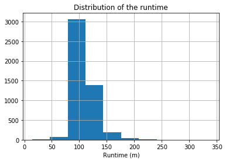

```python
movies.runtime.hist(); #runtime chart
plt.title('Distribution of the runtime') #Title of the chart
plt.xlabel('Runtime (m)') #naming x Axis
```

The chart above is a right skewed, So most movies times between 80 minutes to 120 minutes.

```python
average_runtime= movies.runtime.mean() # get runtime average

print (average_runtime) #print result
```

```
107.66072177926983
```

```python
movies['runtime'].describe() # describe runtime data
```

```
count    4766.000000
mean      107.660722
std        20.749424
min        14.000000
25%        94.000000
50%       104.000000
75%       118.000000
max       338.000000
Name: runtime, dtype: float64
```

# Question 2- Is there a connection between the budget of the movie and its Profit?

1-Displays the chart of budget. 2-Displays the chart of Profit. 3-Displays the chart of budget of the movie and its Profit.

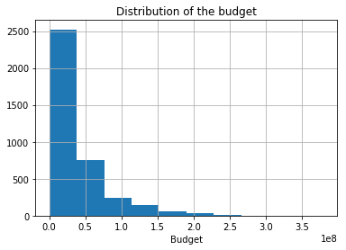

```python
movies.budget.hist(); #budget chart
plt.title('Distribution of the budget') # Title of the chart
plt.xlabel('Budget') #naming x Axis
```

```python
average_budget= movies.budget.mean() # get budget average

print (average_budget)
```

```
37042837.631704725
```

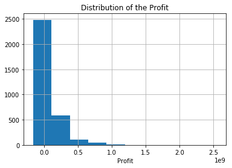

```python
movies.Profit.hist(); #Profit chart
plt.title('Distribution of the Profit') # Title of the chart
plt.xlabel('Profit') #naming x Axis
```

```python
average_Profit= movies.Profit.mean() # get Profit average

print (average_Profit)
```

```
80588512.48714772
```

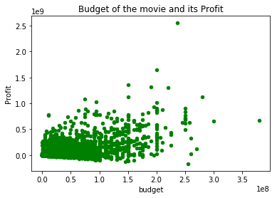

```python
movies.plot(x="budget", y="Profit", kind="scatter" , color = "green");
plt.title('Budget of the movie and its Profit') #naming the title of the visualization
plt.xlabel('budget')# naming x Axis
plt.ylabel('Profit') # naming y Axis
plt.show()
```

# Question 3- What is the name of the movie with the highest profit and the movie with largest budget?

1-Discovery the name of the movie with the highest profit. 2-Discovery the name of the movie with the largest budget.

```python
# create function to get the highest profit
def highest_profit(Profit):

    highest= movies[Profit].idxmax()
    highest_profit=pd.DataFrame(movies.loc[highest])#get the highest profit

    print(highest_profit) # print result

highest_profit('Profit') # call the function
```

```
                                     0
budget                        2.37e+08
Profit                     2.55097e+09
original_language                   en
original_title                  Avatar
popularity                     150.438
release_date       2009-12-10 00:00:00
revenue                    2.78797e+09
runtime                            162
title                           Avatar
```

The name of the movie with the highest profit :Avatar

```python
# create function to get the largest budget
def largest_budget(budget):

    largest= movies[budget].idxmax()
    largest_budget=pd.DataFrame(movies.loc[largest]) #get the largest budget

    print(largest_budget)# print result

highest_profit('budget')# call the function
```

```
                                                            17
budget                                                 3.8e+08
Profit                                             6.65714e+08
original_language                                           en
original_title     Pirates of the Caribbean: On Stranger Tides
popularity                                             135.414
release_date                               2011-05-14 00:00:00
revenue                                            1.04571e+09
runtime                                                    136
title              Pirates of the Caribbean: On Stranger Tides
```

The movie with largest budget:Pirates of the Caribbean: On Stranger Tides

## Conclusions

A few notes about my data cleaning are that in the runtime, budget, and revenue, I encountered some missing cells and cells with zero value, So I replaced it them with (NaN) value. This possibly couldn't have been accurate and will affect the overall analysis.

```python
from subprocess import call
call(['python', '-m', 'nbconvert', 'Investigate_a_Dataset.ipynb'])
```

```
0
```